# IODS course project

Elli Jalo

# About the project

## Learning objectives of the course

During the course I will learn about three themes:

1. How to use open data sets from different sources **(Open data)**
2. How to share my own data, code and results using openly available software tools **(Open Science)**
3. How to apply certain statistical methods **(Data Science)**

## My personal thoughts about the course at the beginning

My main motivation to attend the course was to learn more about R and how to use it for analysing and visualising the data. It took me a while to understand how this course works, but now when I have got started I’m quite excited. It looks like I’m goint to learn a lot.

[A link to my GitHub repository](https://github.com/ejalo/IODS-project)

# RStudio Exercise 2

## Data wrangling

First part of the Exercise 2 was data wrangling. Code that I have used to create data for this excercise can be found in [R script](https://github.com/ejalo/IODS-project/blob/master/data/create_learning2014.R) in my GitHub repository.

## Data analysis

Seconf part of the Exercise 2 was data analysis. I show only the results and interpretation in this course diary. The code behind the analysis can be found in [the chapter2.Rmd](https://github.com/ejalo/IODS-project/blob/master/chapter2.Rmd) in my Github repository.

### Description of the data used for the exercise

In this exercise we use data colleced by Kimmo Vehkalahti between December 2014 and January 2015. Data consists of 166 students. The average (sd) age of the students was 25.5 years. Students filled out questionnaires about their learning strategies and attitudes towards statistics. The items measuring different dimensions (deep/surface/strategic) of learning strategies were averaged to summary scores (deep, stra, and surf). Attitude towards statistics was measured with 10 items, and answers to these items were averaged to summary score (attitude). All summary scores were measured in a scale from 1 to 5. The outcome variable was points obtained from a statistics exam (min 7, max 33).

##### **Figure 2.1** A graphical overwiew of the data

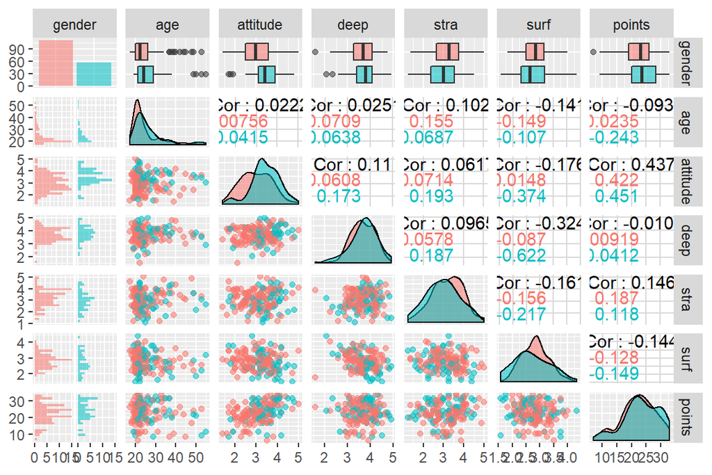

A graphical overview of the data and summaries of the variables in the data are presented in the **Figure 2.1**. Out of students, approximately one third were men. Men were slightly older and had slightly better attitude towards statistics, even though based on boxplots, it is not possible to say if the differences were statistically significant. There were no clear differences in different dimensions of learning and exam points between genders.

Out of continuous variables, all except age were quite normally distributed. Age was skewed towards right, since most of the students were younger than 25 years old, but the oldest were around 50 years old. The highest correlation (0.437) was observed between attitude and exam points. Also strategic learning was positively correlated with exam points (0.146), whereas surface learning was negatively correlated with exam points (-0.144). Observed correlatios were similar in both genders. There seemed to be no association between age or deep learning and exam points.

### Regression model

I chose to explain exam points with attitude and two dimensions of learning (stategic and surcafe), since those variables had the highest absolute correaltions with exam points. The summary of the regression model is presented in **Table 2.1**.

##### **Table 2.1** Summary of the regression model with three explanatory variables (attitude, strategic learning and surface leargning). Dependent variable is exam points.

```
##
## Call:
## lm(formula = points ~ attitude + stra + surf, data = learning2014)
##
## Residuals:
##      Min       1Q   Median       3Q      Max
## -17.1550  -3.4346   0.5156   3.6401  10.8952
##
## Coefficients:
##             Estimate Std. Error t value Pr(>|t|)
## (Intercept)  11.0171     3.6837   2.991  0.00322 **
## attitude      3.3952     0.5741   5.913 1.93e-08 ***
## stra          0.8531     0.5416   1.575  0.11716
## surf         -0.5861     0.8014  -0.731  0.46563
## ---
## Signif. codes:  0 '***' 0.001 '**' 0.01 '*' 0.05 '.' 0.1 ' ' 1
##
## Residual standard error: 5.296 on 162 degrees of freedom
## Multiple R-squared:  0.2074, Adjusted R-squared:  0.1927
## F-statistic: 14.13 on 3 and 162 DF,  p-value: 3.156e-08
```

In the second model, variables that did not have a statitically significant relationship with exam points (startegic and surface learning) were removed. The beta estimate of attitude increased to 3.5 (**Table 2.2**) and the result was still higly significant (p<0.001). Multiple R-squared was 0.19, meaning that attitude alone explained 19% of variance in exam points.

##### **Table 2.2** Summary of the regression model second regression model. Attitude as an explanatory variable and exam points as dependent variable.

```
##
## Call:
## lm(formula = points ~ attitude, data = learning2014)
##
## Residuals:
##      Min       1Q   Median       3Q      Max
## -16.9763  -3.2119   0.4339   4.1534  10.6645
##
## Coefficients:
##             Estimate Std. Error t value Pr(>|t|)
## (Intercept)  11.6372     1.8303   6.358 1.95e-09 ***
## attitude      3.5255     0.5674   6.214 4.12e-09 ***
## ---
## Signif. codes:  0 '***' 0.001 '**' 0.01 '*' 0.05 '.' 0.1 ' ' 1
##
## Residual standard error: 5.32 on 164 degrees of freedom
## Multiple R-squared:  0.1906, Adjusted R-squared:  0.1856
## F-statistic: 38.61 on 1 and 164 DF,  p-value: 4.119e-09
```

### Model validation

In addition to assuming a linear association between explanatory and dependent variable, there are several assumptions regarding residuals (errors) in the linear regression:

1. Residuals should be normally distributed
2. Residuals should be indepent on the explanatory variable(s)
3. Residuals should not be correlated